# Spatial Analysis: 01

Tzai-Hung Wen

2025-02-24

# Hypothesis testing

## 1. Comparing the means

```r
data <- read.csv("./data/Student.csv")
head(data)
```

|  | X.1 | X | Gender | GPA | ReligImp | MissClass | Seat | PartyDays | StudyHrs |
| --- | --- | --- | --- | --- | --- | --- | --- | --- | --- |
| 1 | 1 | 1 | Female | 3.70 | Fairly | 1 | Back | 5 | 3 |
| 2 | 2 | 2 | Male | 3.20 | Fairly | 3 | Front | 3 | 30 |
| 3 | 3 | 3 | Female | 3.01 | Fairly | 0 | Middle | 8 | 16 |
| 4 | 4 | 4 | Female | 3.77 | Not | 0 | Middle | 0 | 4 |
| 5 | 5 | 5 | Male | 3.28 | Not | 0 | Middle | 8 | 12 |
| 6 | 6 | 6 | Female | 2.80 | Fairly | 0 | Middle | 2 | 20 |

```r
aggregate(x = data$GPA,
          by = list(data$Seat),
          FUN = mean)
```

| Group.1 | x |
| --- | --- |
| Back | 3.077015 |
| Front | 3.251284 |
| Middle | 3.193475 |

## 2. Checking the distributions

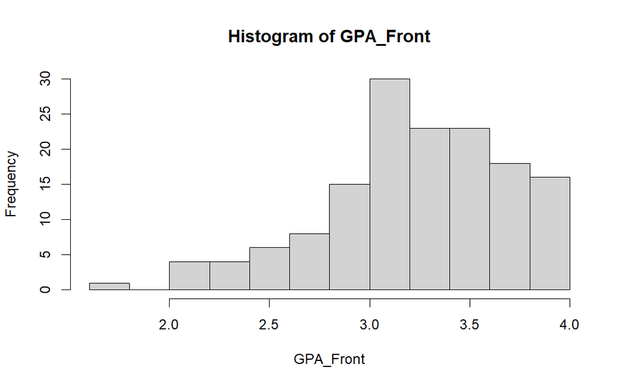

```r
GPA_Back <- data[data$Seat == "Back", ]$GPA
GPA_Front <- data[data$Seat == "Front", ]$GPA

hist(GPA_Front)
```

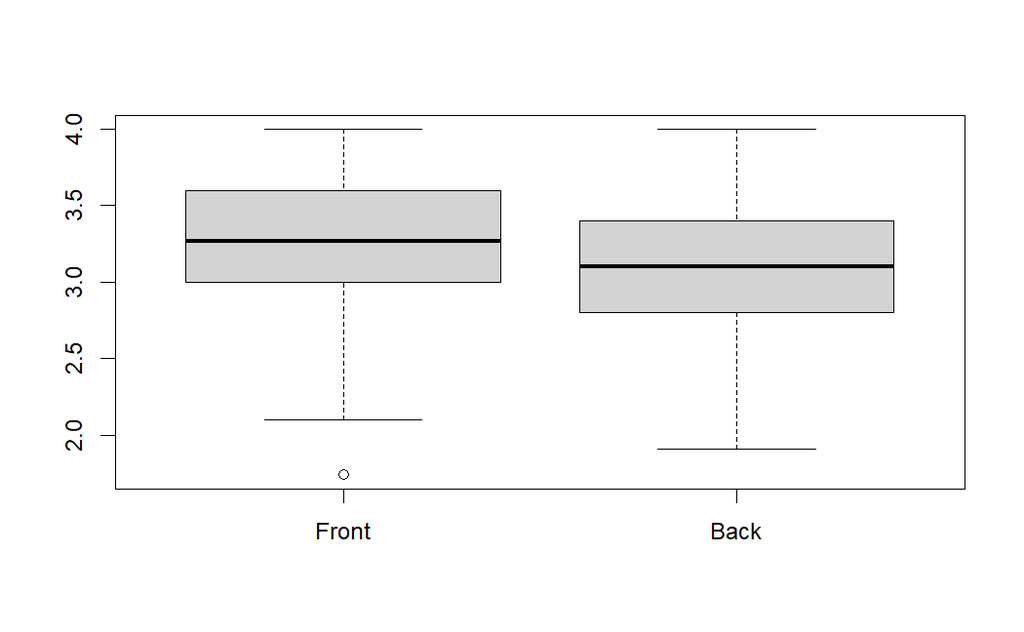

```r
boxplot(GPA_Front, GPA_Back, names = c('Front','Back'))
```

## 3. t-test and inference

```r
t.test(GPA_Back, GPA_Front) # two tailed test
```

```
    Welch Two Sample t-test

data:  GPA_Back and GPA_Front
t = -3.1562, df = 273.52, p-value = 0.001777
alternative hypothesis: true difference in means is not equal to 0
95 percent confidence interval:
 -0.28296881 -0.06556891
sample estimates:
mean of x mean of y
 3.077015  3.251284
```

```r
t.test(GPA_Back, GPA_Front, alternative="less") # one tailed test
```

```
    Welch Two Sample t-test

data:  GPA_Back and GPA_Front
t = -3.1562, df = 273.52, p-value = 0.0008885
alternative hypothesis: true difference in means is less than 0
95 percent confidence interval:
        -Inf -0.08313998
sample estimates:
mean of x mean of y
 3.077015  3.251284
```

```r
t.test(GPA_Front, alternative="greater", mu = 3.2) # one tailed test
```

```
    One Sample t-test

data:  GPA_Front
t = 1.3874, df = 147, p-value = 0.08371
alternative hypothesis: true mean is greater than 3.2
95 percent confidence interval:
 3.190099      Inf
sample estimates:
mean of x
 3.251284
```

# Probability distributions

## 1. Binominal distribution

例題：某網購公司規定消費者在一週內(7 days)對於購買商品可全額退款。 根據過去記錄，平均每週會有2件退貨商品。 請繪製該公司在1個月內(30 days)退貨商品數量的機率分布圖(probability distribution function, PDF)。估計一個月的退貨商品數超過10件的機率。

### random number generation

```r
p = 2/7
n = 30

GenNumbers <- function(){
  x <- sample(1:7, 1, replace=T)
  if (x <= 2) L = 1 else L = 0

  for (i in 1:29) {
    x <- sample(1:7, 1, replace=T)
    if (x <= 2) event = 1 else event = 0
    L = c(L, event)
    sum_L = sum(L)
  }

  return(sum_L)
}
```

### generating distributions

```r
vector_a <- vector()

for (i in 1:1000){
  a <- GenNumbers()
  vector_a <- c(vector_a, a)
}

hist(vector_a, freq = F)
```

[output not shown]

### calculating probability

```r
count_GT10 <- length(vector_a[vector_a>10])
Prob_GT10 <- count_GT10 / 1000
```

### using built-in functions

dbinom(x, size, prob): prob density of x

pbinom(x, size, prob): p(<= x)

qbinom(p, size, prob): quantile function

rbinom(n, size, prob): generates random deviates

```r
# 一個月的退貨商品數超過10件的機率
p = pbinom(10, size=30, prob= 2/7) # prob(X <=10)
(pGT10 <- 1 - p)
```

```
[1] 0.2146092
```

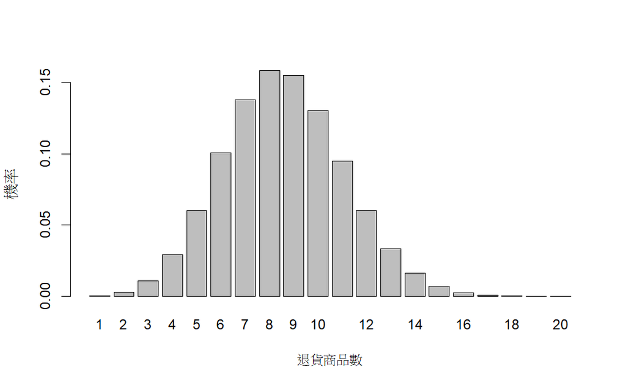

```r
# 1個月內(30 days)退貨商品數量的機率分布圖(PDF)
xlab <- vector()
prob <- vector()
for (i in 1:20){
  xlab[i] <- toString(i)
  prob[i] <- dbinom(i, size=30, prob= 2/7)
}

barplot(prob, names.arg = xlab, xlab="退貨商品數", ylab="機率" )
```

## 2. Normal distribution

```r
dnorm(35, mean=30, sd=5) # DF, P(x=35)
pnorm(35, mean=30, sd=5) # CDF, P(x<=35)
qnorm(0.05, mean=100, sd=15) # given prob. --> x
rnorm(10, mean=100, sd=15)   # generates random deviates x
```

[output not shown]

# Charts and graphics

```r
library(ggplot2)

housing <- read.csv("./data/landdata.csv")
head(housing)
```

|  | State | region | Date | Home.Value | Structure.Cost | Land.Value | Land.Share..Pct. | Home.Price.Index | Land.Price.Index | Year | Qrtr |
| --- | --- | --- | --- | --- | --- | --- | --- | --- | --- | --- | --- |
| 1 | AK | West | 2010.25 | 224952 | 160599 | 64352 | 28.6 | 1.481 | 1.552 | 2010 | 1 |
| 2 | AK | West | 2010.50 | 225511 | 160252 | 65259 | 28.9 | 1.484 | 1.576 | 2010 | 2 |
| 3 | AK | West | 2009.75 | 225820 | 163791 | 62029 | 27.5 | 1.486 | 1.494 | 2009 | 3 |
| 4 | AK | West | 2010.00 | 224994 | 161787 | 63207 | 28.1 | 1.481 | 1.524 | 2009 | 4 |
| 5 | AK | West | 2008.00 | 234590 | 155400 | 79190 | 33.8 | 1.544 | 1.885 | 2007 | 4 |
| 6 | AK | West | 2008.25 | 233714 | 157458 | 76256 | 32.6 | 1.538 | 1.817 | 2008 | 1 |

```r
NA
```

## 1. Histogram

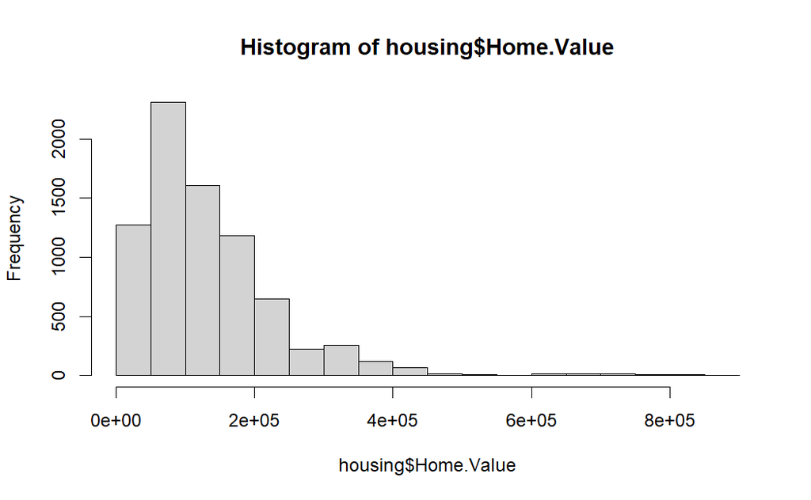

```r
hist(housing$Home.Value)
```

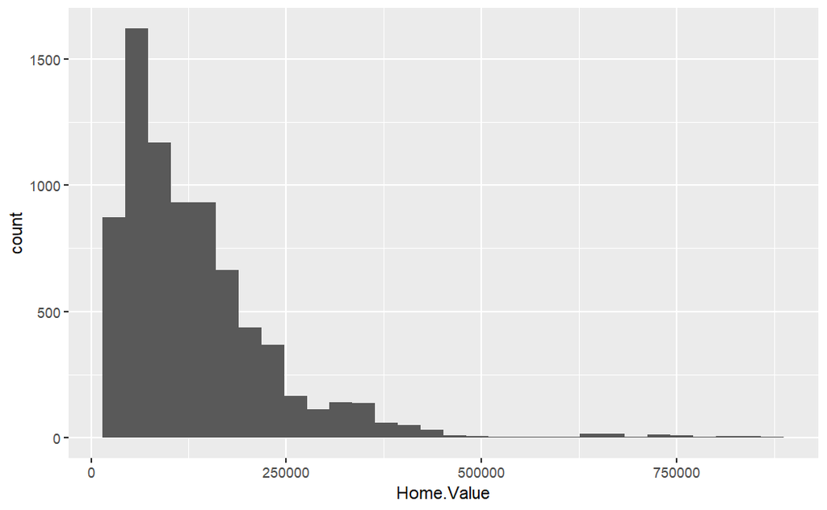

```r
ggplot(housing) + aes(x = Home.Value) + geom_histogram()
```

## 2. Scatterplot

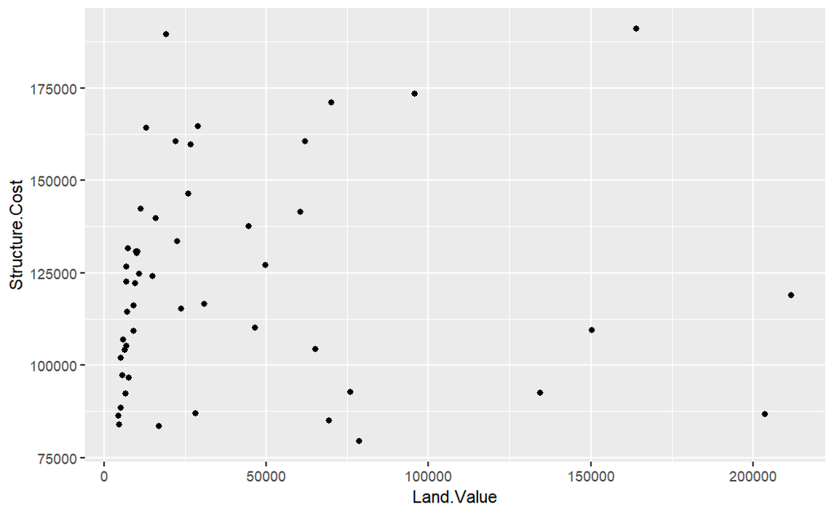

```r
hp2001Q1 <- subset(housing, Date == 2001.25)
ggplot(hp2001Q1) + aes(y = Structure.Cost, x = Land.Value) + geom_point()
```

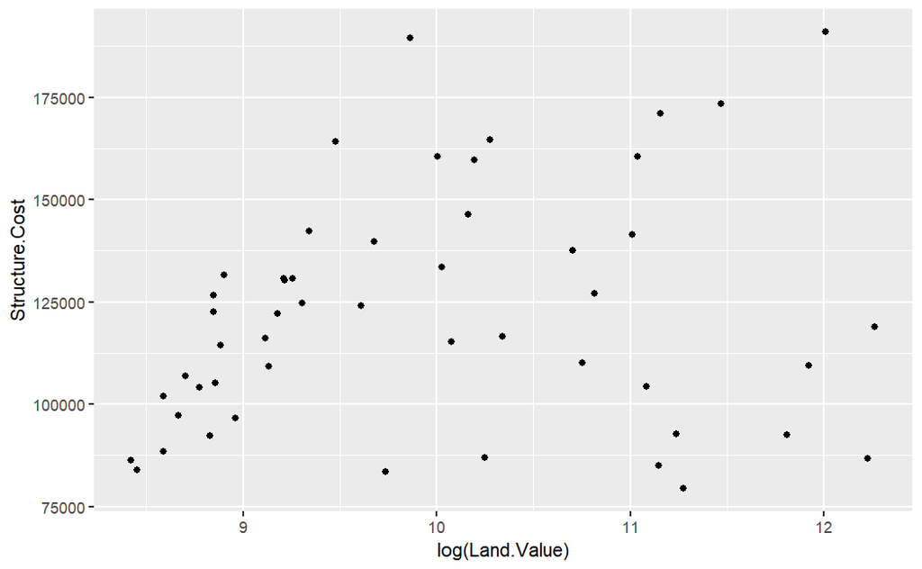

```r
ggplot(hp2001Q1) + aes(y = Structure.Cost, x = log(Land.Value)) + geom_point()
```

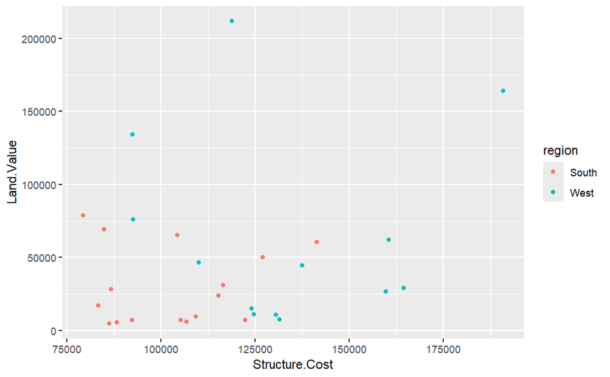

```r
# more complex
seldata <-subset(hp2001Q1, region %in% c("South", "West"))
# seldata2 <-subset(housing, Date == 2001.25 & region %in% c("South", "West"))
ggplot(seldata) + aes(x=Structure.Cost, y=Land.Value, color=region) + geom_point()
```

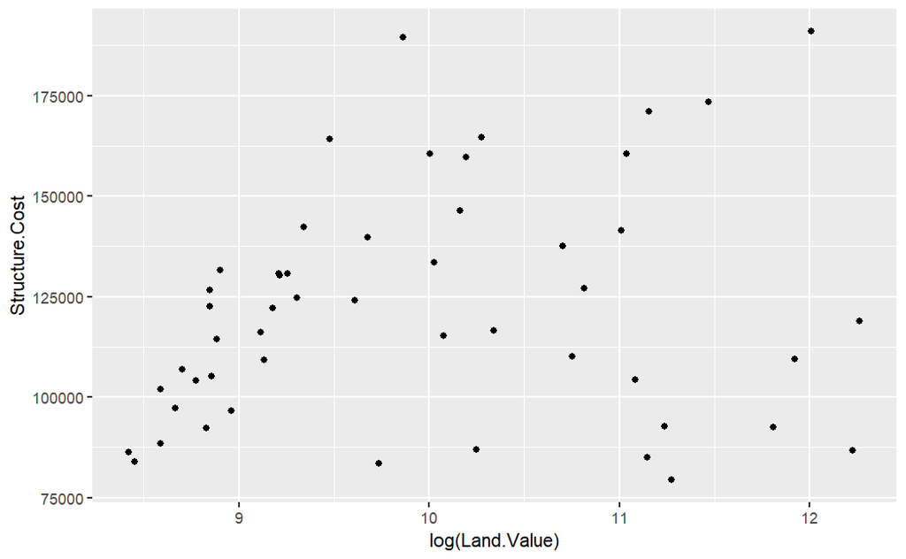

```r
p1 <- ggplot(hp2001Q1) + aes(x = log(Land.Value), y = Structure.Cost)

p1 + geom_point()
```

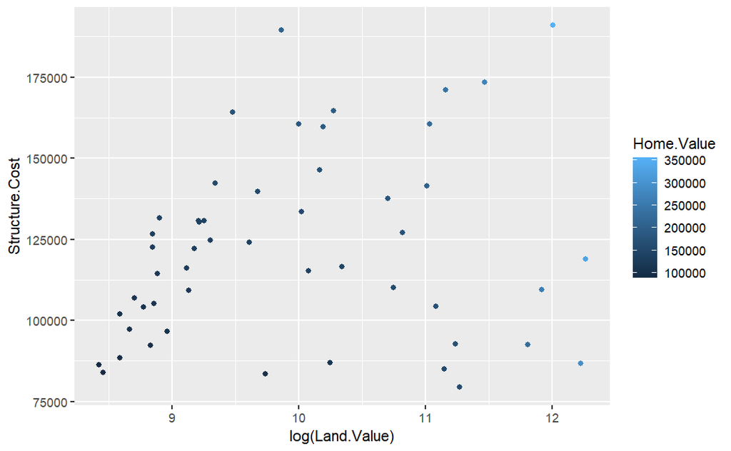

```r
p2 <- p1 + geom_point(aes(color = Home.Value)) # setting dot color or size
p2
```

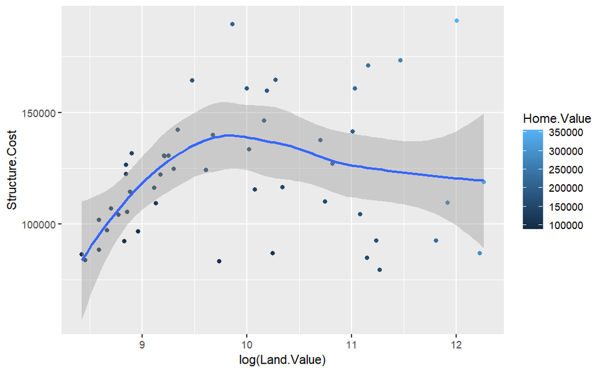

```r
p2 + geom_smooth()
```

## 3. Bar chart

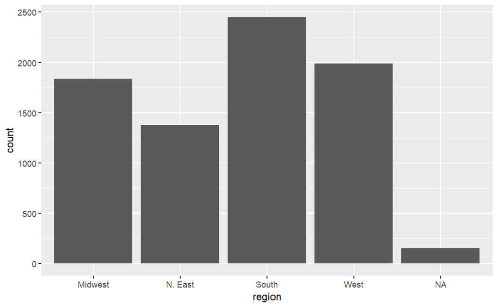

```r
ggplot(housing) + aes(x=region) + geom_bar()
```

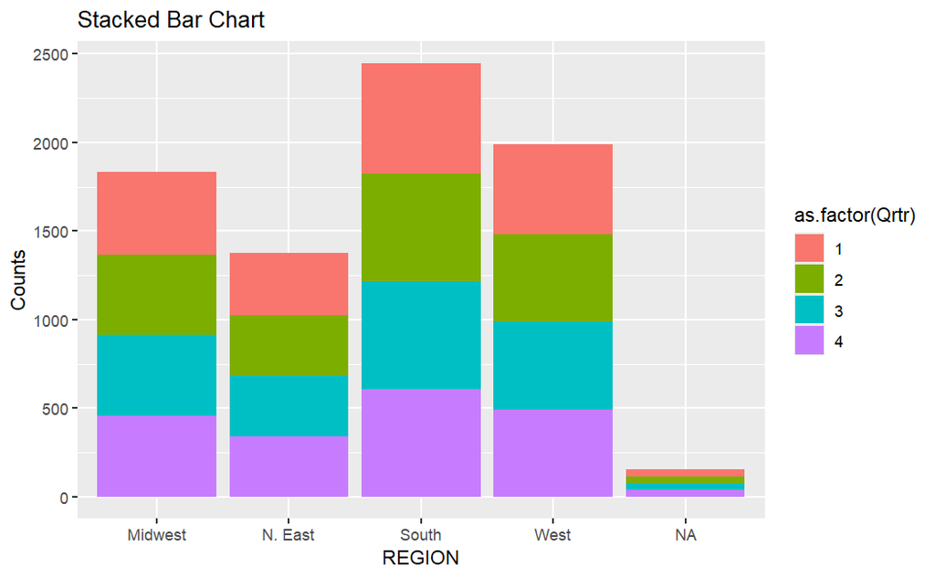

```r
# Stacked Bar Chart
ggplot(housing) + aes(x=region, fill= as.factor(Qrtr)) + geom_bar() +
  labs(title = "Stacked Bar Chart", x = "REGION", y = "Counts")
```

```r
# ?aggregate
# aggregate(x, by, FUN...)
housing.sum <- aggregate(housing["Home.Value"], housing["State"], FUN=mean)
head(housing.sum)
```

|  | State | Home.Value |
| --- | --- | --- |
| 1 | AK | 147385.14 |
| 2 | AL | 92545.22 |
| 3 | AR | 82076.84 |
| 4 | AZ | 140755.59 |
| 5 | CA | 282808.08 |
| 6 | CO | 158175.99 |

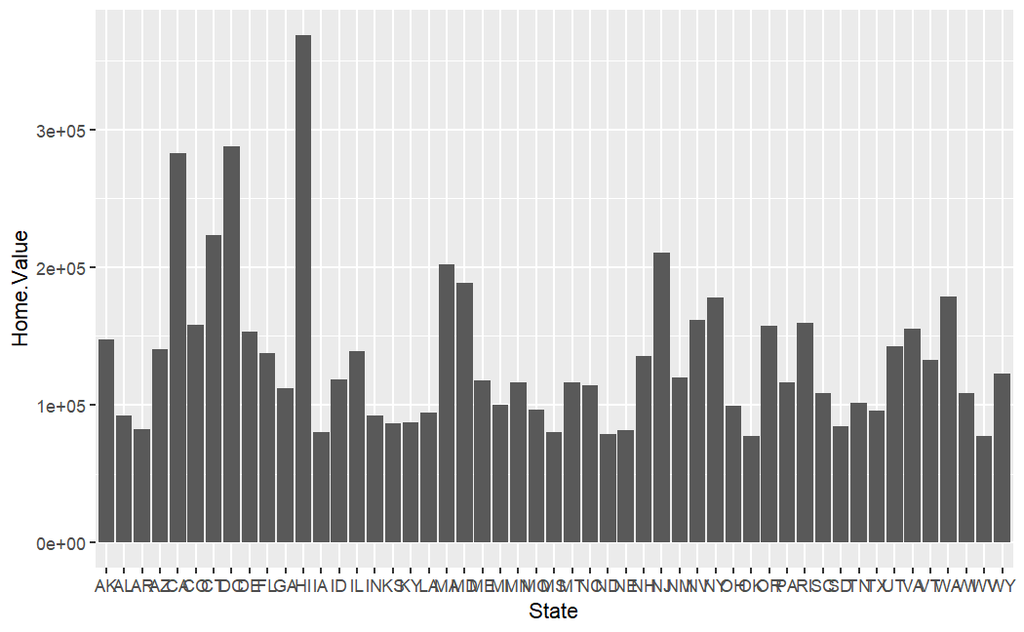

```r
# ggplot(housing.sum) + aes(x=State, y=Home.Value) + geom_bar() # WRONG
ggplot(housing.sum) + aes(x=State, y=Home.Value) + geom_bar(stat='identity')
```

## 4. Pie chart

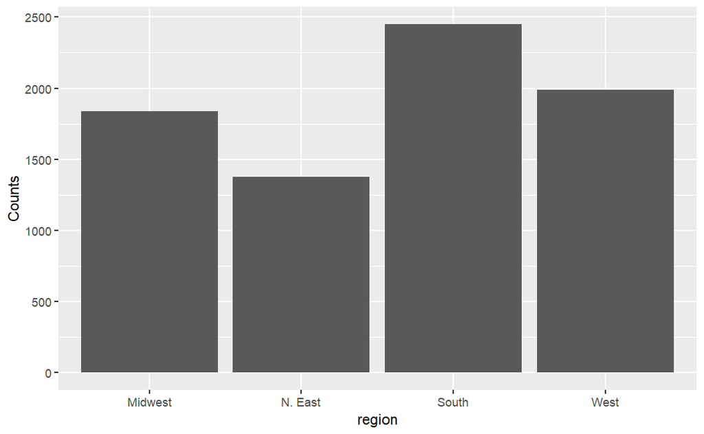

```r
housing2.sum <- aggregate(housing["Home.Value"], housing["region"], FUN=length)
ggplot(housing2.sum) + aes(x=region, y=Home.Value) + geom_bar(stat='identity') + labs(y="Counts")
```

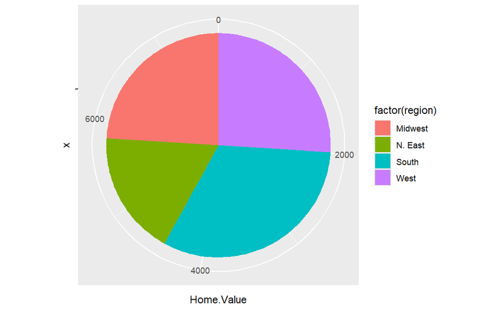

```r
ggplot(housing2.sum) + aes(x="", y=Home.Value, fill = factor(region)) +
  geom_bar(stat='identity',width=1) + coord_polar(theta = "y", start=0)
```

## 5. Box plot

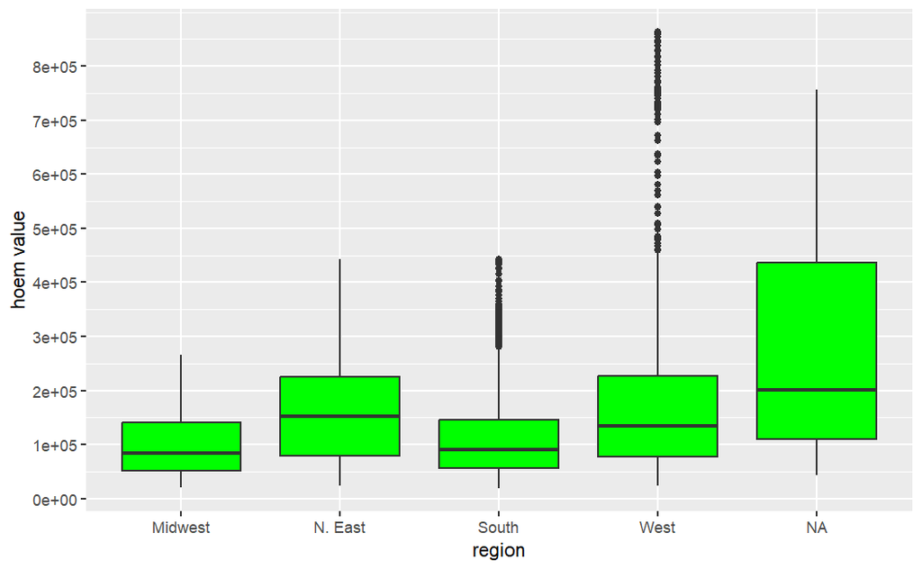

```r
ggplot(housing) + aes(x = region, y= Home.Value) + geom_boxplot(fill = "green")+
  scale_y_continuous("hoem value", breaks= seq(0,800000, by=100000))
```

## 6. Heat map

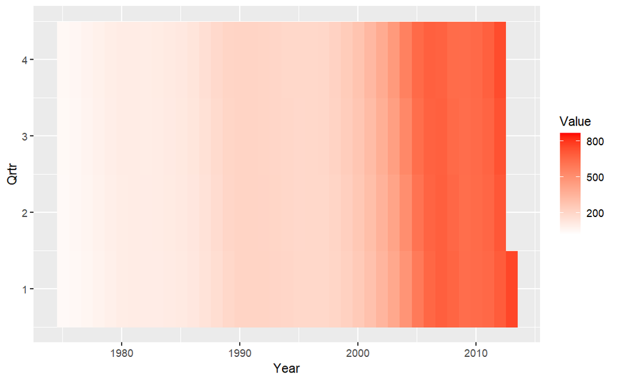

```r
ggplot(housing) + aes(x= Year, y= Qrtr) + geom_raster(aes(fill = Home.Value)) +
  scale_fill_continuous(name="Value", breaks = c(200000, 500000, 800000),
                        labels = c("200", "500", "800"), low='white', high='red')
```

## 7. Combined plots

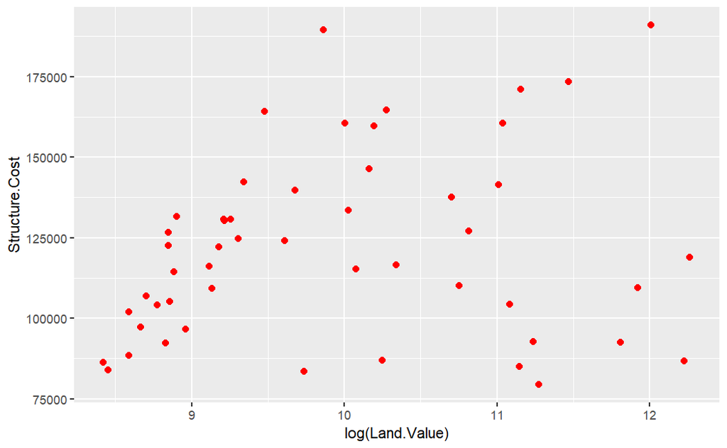

```r
## Combine Scatter plot + marginal histogram/box plot
## install.packages("ggExtra")
library(ggExtra)
p1 <- ggplot(hp2001Q1) + aes(x = log(Land.Value), y = Structure.Cost)
p1 + geom_point(size = 2, color="red")
```

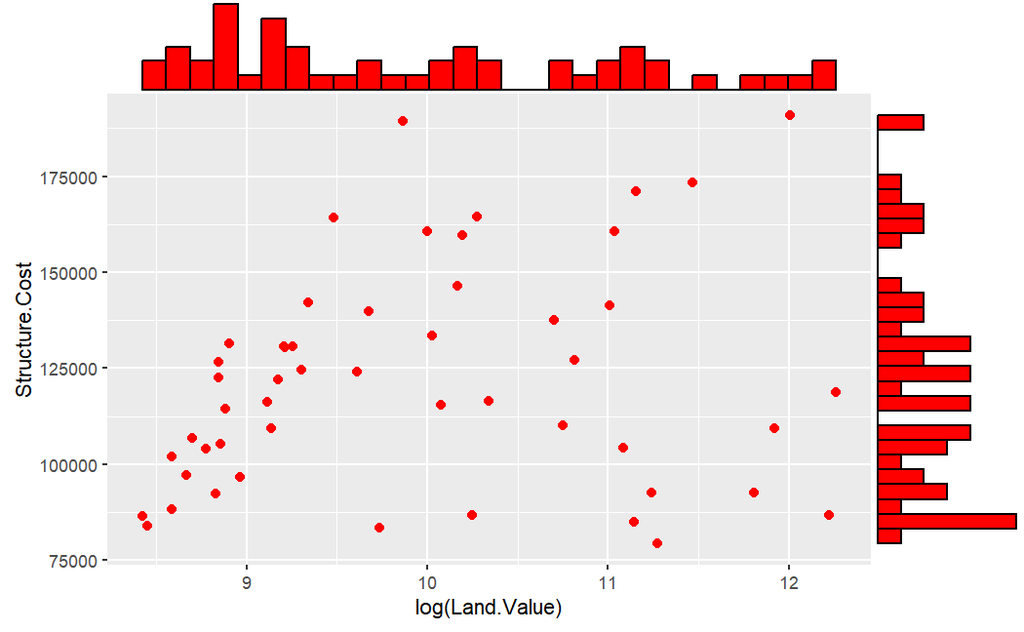

```r
px<- p1 + geom_point(size = 2, color="red")
ggMarginal(px, type = "histogram", fill="red")
```

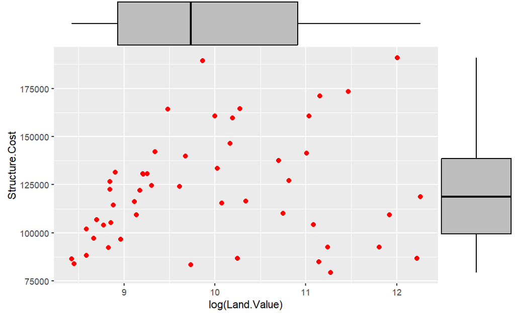

```r
ggMarginal(px, type = "boxplot", fill="gray")
```

# Assignments

## 1.機率分布

(a).某一都市有10萬人口，假設流行一種新興疾病，每人每年被感染機率 p = 0.01， 沒有免疫與任何預防措施。請繪製該市的每年感染人數頻率分布圖。

(b).該市衛生當局定義若某年的感染人數超過960人，該年則視為疫情爆發。 市長的任期是4年，若任期內爆發疫情事件，就必須辭職下台。 請評估市長在任期四年內，因疫情爆發而辭職的機率?

## 2. 繪製統計圖表與統計檢定(Student.csv)

(a). 比較不同性別(Gender)，其讀書時間(StudyHrs)是否有顯著差異？

(b). 比較不同性別(Gender)，對於虔誠信仰宗教的比例(ReligImp)是否有顯著差異？